# Eye Tracking - Visual Search

Computational Modelling - Portfolio 1

Magnus Knudsen, Victor Møller, Anders Weile, Jan Kostkan, Carl-Magnus Christiansen

2019-02-22

# Hypotheses

Examining a visual scene involves employing a search strategy which may engage goal representations and taking the properties of a particular scene into account. While these so-called extrinsic factors can change across different visual scenes and different tasks, intrinsic factors remain constant. These intrinsic factors could be heuristics, i.e. computational that could be applied in a task-independent manner. To examine whether extrinsic factors partially drive visual search, we make the following hypothesis:

Code At our Github

- **H1**: Visual search patterns are affected by extrinsic factors.

# Methods

## Experiment description

In this experiment, participants are presented with various visual scenes, all containing both countable elements (e.g. sheep) and a hidden star. The experiment is further divided into two blocks, depending on condition. Each participant is presented with 5 different images in each experimental block, adding up to a total of 10 images per participant.

Participants are given one of two tasks in each experimental block (condition): either to locate the hidden star or to count the elements. Images are shown in one of two orders (independent of the task at hand), but participants were always be assigned to the counting task first. Each picture is shown for 20 seconds, with a short pause between the experimental blocks, during which instructions about the new task are given to the participants.

## Device and calibration

Device used for the eye tracking itself was an EyeLink 1000 table-mounted eye tracker and only the dominant eye (self-reported by each participant) was tracked. Participants were approximately 60 cm away from the screen and their heads remained in a chin-rest for the duration of the experiment. Eye movement was recorded with a sampling rate of a 1000hz.

The data was collected in two session that took place one year apart. The device was calibrated for each of the six participants individually during the first session in 2018. However, the remaining six participants, who attended the second session in 2019 were recorded using legacy calibration settings from the first session, due to urgent technical difficulties (unauthorized personnel reprogrammed the recording device).

## Participants

A total of 12 participants attended the experiment in both sessions. Out of that, 4 were males and 8 were females. Participants were equally distributed between the two possible image orders and as all participants were also scheduled to complete both tasks (star searching and element counting).

However, one participant in the 2018 session did not complete the whole experiment. The drop out occurred during their 4th trial (image), which was thus left only about 30% finished. For this reason, we decided to exclude said trial from our analysis, while keeping the first three trials this participant completed.

## Preprocessing

Recordings were of either left or right eye, depending on participant’s eye dominance. As no participant had both their eye tracked, these records could be combined into a single record of the dominant eye. Resulting data were then used to estimate events.

### Estimating events

Choosing parameters for visual events, i.e. what the eye-tracker counted as a saccade and a fixation, was our first cause of concern. There are no rigid definitions of what constitutes different events in eye-tracking research, though some proposed thresholds are given in the literature. Often, researchers copy the parameters used in previous experiments to have a baseline to which they can compare their results. We choose parameters on the less conservative end.

We used a rolling window of 200 ms to compute the “probability” of each data point to be in a fixation or a saccade. We then chose a threshold of probability (.85) in order for something to be considered a fixation or a saccade.

Fixations and saccades were calculated from mean velocities, defining saccades as exceeding a threshold of 15 degrees per second in a window of 200 ms while fixations were defined as being below this threshold.

If we were trying to replicate the study in the “real world”, we would of course use the same parameters, given by the Eyelink software. But since this was an exercise, we thought it better to use something that wasn’t a blackbox to us.

```
##  [1] "2018-1_1_f1"  "2018-2_2_f2"  "2018-3_1_f1"  "2018-4_2_F1"
##  [5] "2018-5_1_m2"  "2018-6_3_m2"  "2019-1_1_m11" "2019-2_2_f22"
##  [9] "2019-3_1_f11" "2019-4_2_m12" "2019-5_1_f21" "2019-6_3_f22"
```

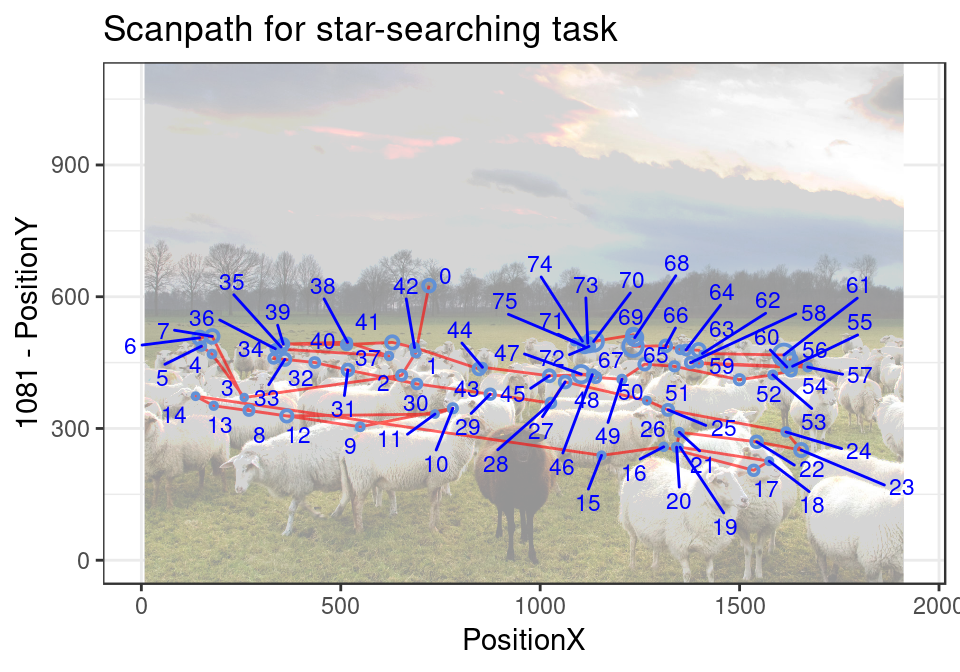

Example of a scan path for the star-search condition

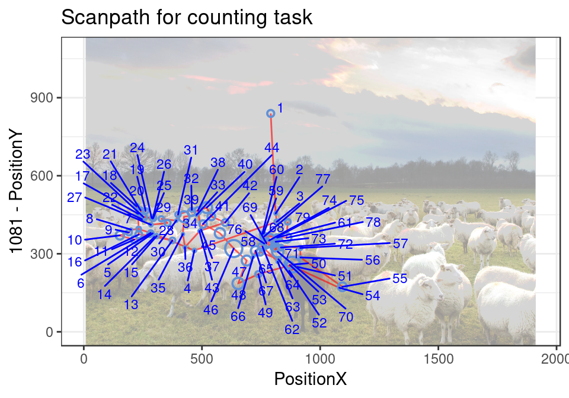

Example of a scan path for the counting condition

### Found-star trials

Since we are primarily interested in the actual visual search, we excluded instances of fixations where participants found the star because including these would obscure our analysis. We plotted scan-paths for each visual search trial and manually searched for clusters of fixations around the end of trials. Based on this, we excluded clusters of fixations in 3 trials, where we were certain the star was found. Only this last cluster of fixations were excluded; the rest of the fixations in the trial was left untouched.

Fixations and saccades were subsequently divided into to datasets, and variables like amplitude and duration were calculated.

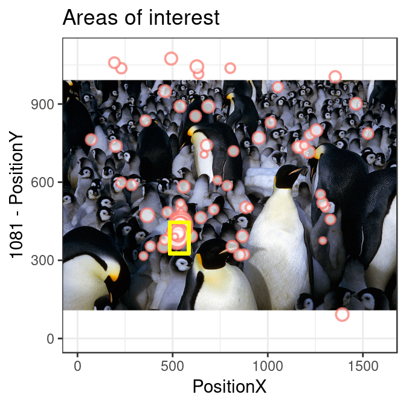

Example of an excluded trial where the participant found the star

```
## [1] "VisualSearch_Count" "VisualSearch_Star"
```

Fixation duration by task in milliseconds

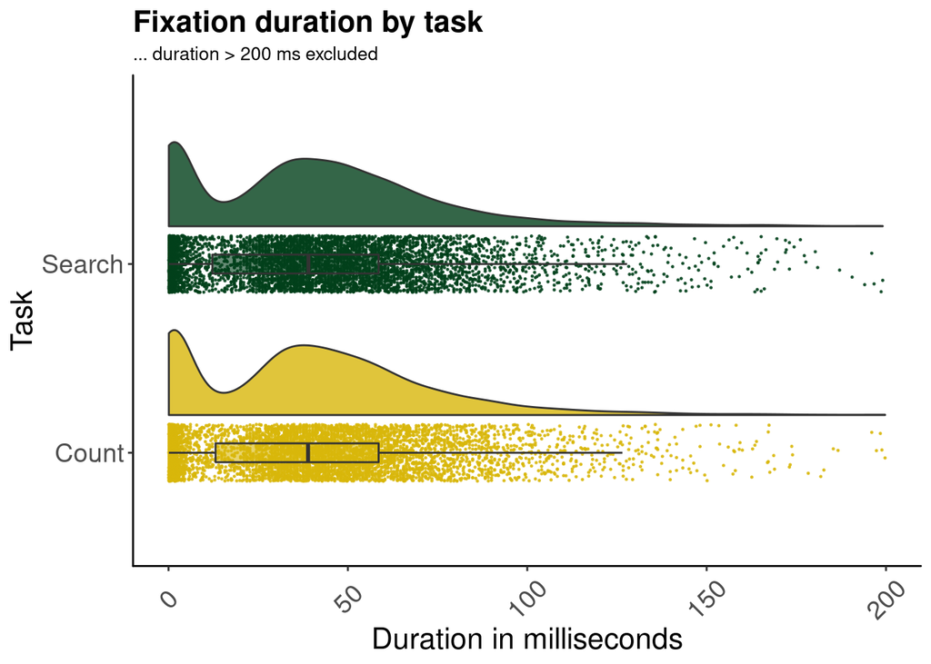

## Models

From H1, we expect that the task assigned to the participants to affect properties of their eye movements. We selected three properties to serve as the dependent variables of three different models, namely the durations of fixations, the number of saccades, and the saccade amplitudes. The fixed and random effects were similar across the three models. In accordance with H1, each model had task as a fixed effect. In addition, we used time as a fixed effect to test the effect of time on our dependent variables. Since each item was used in both tasks, we allowed items to vary in the dependent measures across the two tasks and including this in the random structure of the models. Similarly, participants were allowed to vary across tasks, since every participant did both the counting and star-finding tasks. We also included time in this random slope since participants may become fatigued at different rates.

From these considerations, we constructed the following three models:

`Model1 <- glmer(Duration ~ Task + StartTime + (1 + Task | Item) + (1 + Task + StartTime | ParticipantID), family = gaussian(link=log), data = Fixations_VS_3, control = glmerControl(optimizer = "nloptwrap", calc.derivs = FALSE))`

`Model2 <- glmer(SaccadeNum ~ Task + StartTime + (1 + Task | Item) + (1 + Task + StartTime | ParticipantID), family = gaussian(link=log), data = Saccades_VS_3, control = glmerControl(optimizer = "nloptwrap", calc.derivs = FALSE))`

`Model3<- glmer(Amplitude_comb ~ Task + StartTime + (1 + Task | Item) + (1 + Task + StartTime | ParticipantID), family = gaussian(link=log), data = Saccades_VS_2, control = glmerControl(optimizer = "nloptwrap", calc.derivs = FALSE))`

# RESULTS

### Model 1, Fixation Duration

Model 1, Predicting Fixation Duration

|  | Duration |  |  |
| --- | --- | --- | --- |
| Predictors | Estimates | CI | p |
| (Intercept) | -4.78 | -4.94 – -4.62 | **<0.001** |
| TaskSearch | -0.08 | -0.11 – -0.05 | **<0.001** |
| StartTime | 0.18 | 0.07 – 0.29 | **0.001** |
| Observations | 12398 |  |  |

### Model 2, Number of Saccades

Model 2, Predicting Nr. of Saccades

|  | Saccade Num |  |  |
| --- | --- | --- | --- |
| Predictors | Estimates | CI | p |
| (Intercept) | -3.41 | -3.49 – -3.33 | **<0.001** |
| TaskVisualSearch_Star | 0.38 | 0.31 – 0.44 | **<0.001** |
| StartTime | 3.67 | 3.50 – 3.83 | **<0.001** |
| Observations | 12318 |  |  |
| Marginal R<sup>2</sup> / Conditional R<sup>2</sup> | 0.984 / 0.998 |  |  |

### Model 3, Saccade Amplitude

Model 3, Predicting Saccade Amplitude

|  | Amplitude comb |  |  |
| --- | --- | --- | --- |
| Predictors | Estimates | CI | p |
| (Intercept) | -2.65 | -2.77 – -2.53 | **<0.001** |
| TaskVisualSearch_Star | 0.20 | 0.05 – 0.35 | **0.009** |
| StartTime | -0.50 | -0.63 – -0.36 | **<0.001** |
| Observations | 12318 |  |  |
| Marginal R<sup>2</sup> / Conditional R<sup>2</sup> | 0.339 / 0.819 |  |  |

# Discussion & conclusion

Our models appear to indicate that extrinsic factors to some extent drive visual search which is what we hypothesized (H1).

One major problem of this study is that we have a very small number of participants. Although testing several dependent variables bolsters our finding somewhat, this cannot rescue the study from the fact that the power is way too low to draw any reliable conclusion. This is partially due to failure of equipment and loss of data in consequence.

Furthermore, the link between the significance of our models and the correctness of our hypothesis is not clear. Because we have the rather vague hypothesis that visual search patterns are affected by extrinsic factors, any significant effect of an extrinsic factor will suffice to validate our hypotheses. But we are not actually explicitly testing any extrinsic factors and hence we do not gain any insights into what concrete factors may drive visual search. Extrinsic factors are a rather diverse set of factors which allows us only to make very weak and broad statements from our findings.